# Simulating survival times from a General Hazard structure with a flexible baseline hazard

[F. Javier Rubio](https://sites.google.com/site/fjavierrubio67/)

July 01, 2019

# The General Hazard Structure

Throughout, we express the different hazard structures below via the hazard function $h()$ and the cumulative hazard function $H()$, respectively, according to time $t$ and a vector of covariates ${\bf x}_j$. We assume that the vector of covariates does not contain an intercept, in order to avoid identifiability issues. The survival function can be obtained from the relationship $S(t) = \exp[-H(t)]$. The vector $\beta$ denotes the unknown regression parameters.

The following hazard structures have been largely studied and used in the statistical literature:

- Proportional hazards model (PH).
  $$h^{\text{PH}}\left(t;{\bf x}_j\right) = h_0(t)\exp\left({\bf x}_j^{\top}\beta\right),$$
  $$H^{\text{PH}}\left(t;{\bf x}_j\right) = H_0(t)\exp\left({\bf x}_j^{\top}\beta\right).$$
- Accelerated failure time model (AFT).
  $$h^{\text{AFT}}\left(t;{\bf x}_j\right) = h_0\left(t \exp({\bf x}_j^{\top}\beta)\right)\exp({\bf x}_j^{\top}\beta),$$
  $$H^{\text{AFT}}\left(t;{\bf x}_j\right) = H_0\left(t \exp({\bf x}_j^{\top}\beta)\right).$$
  Consider now the following general hazard (GH) structure
- General hazards model (GH).
  $$h^{\text{GH}}\left(t;{\bf x}_j\right) = h_0\left(t \exp({\bf x}_j^{\top}\beta_1)\right)\exp({\bf x}_j^{\top}\beta_2),$$
  $$H^{\text{GH}}\left(t;{\bf x}_j\right) = H_0\left(t \exp({\bf x}_j^{\top}\beta_1)\right)\exp(-{\bf x}_j^{\top}\beta_1+{\bf x}_j^{\top}\beta_2).$$

This is a rich hazard structures that contains both the PH (when $\beta_1=0$) and the AFT (when $\beta_1=\beta_2$) hazard structures (see Chen and Wang (2000), Chen and Jewell (2001), Chen, Jewell, and Yang (2003), and Rubio et al. (2018) for extensive discussion). In addition, it contains the following hazard structure for the cases $\beta_2=0$.

- Accelerated hazards model (AH).
  $$h^{\text{AH}}\left(t;{\bf x}_j\right) = h_0\left(t \exp({\bf x}_j^{\top}\beta)\right),$$
  $$H^{\text{AH}}\left(t;{\bf x}_j\right) = H_0\left(t \exp({\bf x}_j^{\top}\beta)\right)\exp(-{\bf x}_j^{\top}\beta).$$

Consequently, the GH hazard structure can capture time-dependent effects (through $\beta_1$) as well as effects that only affect the hazard level (through $\beta_2$).

# Choosing the baseline hazard

In order to complete the GH model, we need to select a baseline hazard $h_0$. Ideally, we would like to use a parametric distribution that can capture a variety of shapes, such as increasing, decreasing, bathtub, and unimodal (up then down). See Rubio et al. (2018) for a discussion on this point. There exist a couple of options, such as the Generalised Weibull distribution, the Exponentiated Weibull distribution, the Generalised Gamma distribution, among others.

In this tutorial, and for the sake of simplicity, we will only consider the Exponentiated Weibull (EW) distribution, which is implemented and described at [this link](http://rpubs.com/FJRubio/EWD).

The GH hazard structure with EW baseline hazard has been recently used in the context of cancer epidemiology in Rubio et al. (2018) and Rubio et al. (2019), see:

1. [Parametric Excess Hazard Estimation: Proportional Hazards](http://www.rpubs.com/FJRubio/GHPH)
2. [Parametric Excess Hazard Estimation: General Hazards](http://www.rpubs.com/FJRubio/GHGH)
3. [Simulation design I: Excess hazard models for insufficiently stratified life tables](http://www.rpubs.com/FJRubio/FGH)

# Simulating times to event from the GH structure with a generic baseline hazard

Given the simple, though rich, functional expression of the GH structure, simulating from this model is simple using the Probability Integral Transform (PIT).

The idea is to simulate a uniform number $u\sim U(0,1)$, and to apply the PIT directly on the survival associated to the GH structure (recall that, if $U\sim U(0,1)$, then $1-U\sim U(0,1)$). This is, we need to solve the equation,

$$S_{GH}(t) = \exp\left(-H^{\text{GH}}\left(t;{\bf x}_j\right) \right) = u,$$
in terms of $t$. The steps for solving this equation are presented below,
$$S_{GH}(t) = \exp\left(-H^{\text{GH}}\left(t;{\bf x}_j\right) \right) = u.$$
Then,
$$\exp\left\{-H_0\left(t \exp({\bf x}_j^{\top}\beta_1)\right)\exp(-{\bf x}_j^{\top}\beta_1+{\bf x}_j^{\top}\beta_2) \right\} = u,$$
$\Rightarrow$
$$S_0\left(t \exp({\bf x}_j^{\top}\beta_1)\right)^{\exp(-{\bf x}_j^{\top}\beta_1+{\bf x}_j^{\top}\beta_2)} = u,$$
$\Rightarrow$
$$\log S_0\left(t \exp({\bf x}_j^{\top}\beta_1)\right) = \dfrac{\log(u)}{{\exp(-{\bf x}_j^{\top}\beta_1+{\bf x}_j^{\top}\beta_2)}},$$
$\Rightarrow$
$$F_0\left(t \exp({\bf x}_j^{\top}\beta_1)\right) = 1-\exp\left\{\log(u)\exp({\bf x}_j^{\top}\beta_1-{\bf x}_j^{\top}\beta_2)\right\}.$$
Thus, for a general choice of $F_0$ we have
$$t = \dfrac{F_0^{-1}\left[1-\exp\left\{\log(u)\exp({\bf x}_j^{\top}\beta_1-{\bf x}_j^{\top}\beta_2)\right\}\right]}{\exp({\bf x}_j^{\top}\beta_1)}.$$

# Example: Exponentiated Weibull baseline hazard

For the particular of the choice of the EW distribution baseline hazard, where $F_0(t)=F_W^{\alpha}(t)$ and $F_W$ is the Weibull CDF (see [this link](http://rpubs.com/FJRubio/EWD)), we obtain:
$$t = \dfrac{F_W^{-1}\left[\left(1-\exp\left\{\log(u)\exp({\bf x}_j^{\top}\beta_1-{\bf x}_j^{\top}\beta_2)\right\}\right)^{\frac{1}{\alpha}}\right]}{\exp({\bf x}_j^{\top}\beta_1)},$$
where $F_W^{-1}$ is the Weibull quantile function, with fixed shape and scale parameters. Thus, this expression provides a simple way for simulating times to event with GH structure.

The following R code illustrates the implementation of this simulation strategy. We also illustrate how to fit a model with GH structure in the context of administrative censoring at 10 years of follow-up, adapting the R code in [this link](http://www.rpubs.com/FJRubio/GHGH).

# Simulation in R

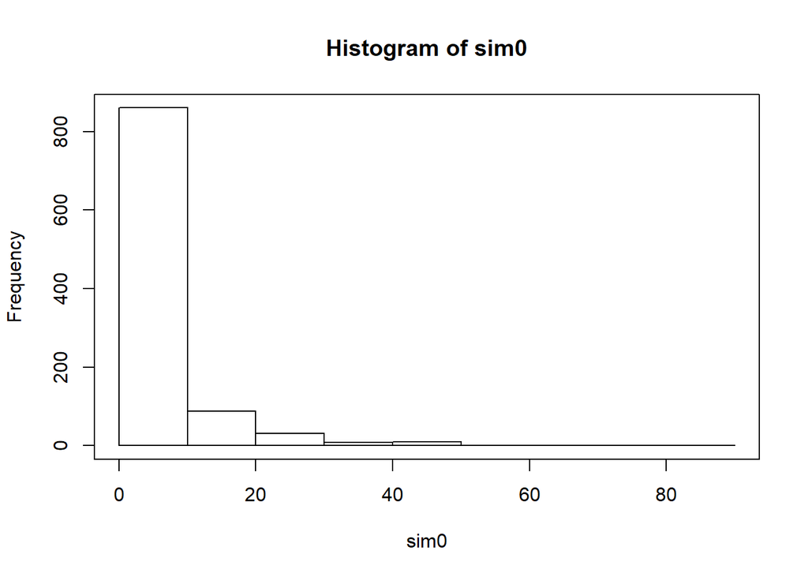

```r
rm(list=ls())
library(knitr)
library(mvtnorm)
####################################################################################
# seed      : seed for simulation
# parEWH    : shape, scale, and power parameters of the EW baseline hazard
# beta      : regression parameters multiplying the hazard
# betaH     : regression parameters multiplying the time scale
# n         : sample size
# X         : Design matrix
####################################################################################

# Function to simulate times to event from a model with EW baseline hazard
# and GH structure
simGHEW <- function(seed, n, X, parEWH, betaH, beta){
  a0 <- parEWH[1]; b0 <- parEWH[2]; c0 <- parEWH[3];
  exp.xbetaH  <- exp(X%*%betaH)
  exp.dif <- exp(X%*%(betaH - beta))
  # Simulation
  set.seed(seed)
  temp.ut1  <- runif(n)
  lifestimes <-  qweibull( ( 1 - exp( log(temp.ut1)*exp.dif ) )^(1/c0), scale=a0, shape=b0)/exp.xbetaH
  return(as.vector(lifestimes))
}



#################################################################################
# Example 1
#################################################################################
seed1 <- 4
# True values of the parameters
a0 <- 1.75; b0 <- 0.7; c0 <- 2.5; beta <- c(0.2,0.3,0.4); betaH = c(0.4,0.3,0.2)
n = 1000 # sample size

# Simulated design matrix
corr = 0.5
p <- length(beta)
X.Sigma <- matrix(corr, nrow=(p), ncol=(p)) + diag(p)*(1 - corr) # Correlation matrix
set.seed(seed1)
X= rmvnorm(n, sigma=X.Sigma) # Design matrix

# Simulated life times
sim0 <- simGHEW(seed1, n, X, c(a0,b0,c0), betaH, beta)
hist(sim0)
box()
```

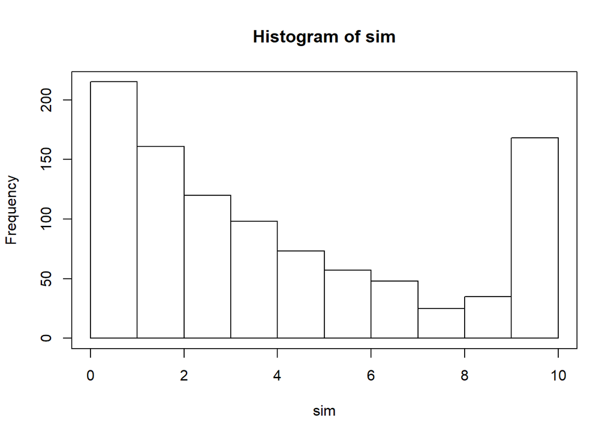

```r
# Inducing non-informative censoring at C
C <- 10
sim <- ifelse(sim0 < C, sim0, C)
ind.cens <- ifelse(sim0 < C, 1, 0)
hist(sim)
box()
```

```r
# Censored proportion
1-mean(ind.cens)
```

```
## [1] 0.14
```

```r
#--------------------------------------------------
# Fitting a survival model with GH structure
#--------------------------------------------------

# Exponentiated Weibull Distribution #
######################################
# Hazard
hexpw <- function(t,lambda,kappa,alpha){
  pdf0 <-  alpha*dweibull(t,scale=lambda,shape=kappa)*pweibull(t,scale=lambda,shape=kappa)^(alpha-1)
  cdf0 <- pweibull(t,scale=lambda,shape=kappa)^alpha
  return(pdf0/(1-cdf0))
}

# Cumulative hazard
Hexpw <- function(t,lambda,kappa,alpha,log.p=FALSE){
  cdf <- pweibull(t,scale=lambda,shape=kappa)^alpha
  return(-log(1-cdf))
}


#--------------------------------------------------------------------------------------------------------
# General Model
#--------------------------------------------------------------------------------------------------------

#----------------------------------------------
# log-likelihood: EW Model
#----------------------------------------------
log.likewG <- function(par){
  if(anyNA(par)) return(Inf)
  ae0 <- par[1]; be0 <- par[2]; ce0=par[3]; beta0 <- par[4:(4+dim(X)[2]-1)]; beta1 <- tail(par,n = dim(X)[2]);
  if(par[1]>0 & par[2]>0 & par[3]>0){
    exp.x.beta0 <- exp(X%*%beta0)
    exp.x.beta1 <- exp(X%*%beta1)
    exp.x.dif <- exp(X%*%(beta1-beta0))
    haz0 <- hexpw(sim*exp.x.beta0,ae0,be0,ce0)*exp.x.beta1
    CH0 <- Hexpw(sim*exp.x.beta0,ae0,be0,ce0)*exp.x.dif
    if(anyNA(CH0)) return(Inf)
    if(anyNA(haz0)) return(Inf)
    else  val <- - ind.cens*log(haz0) + CH0
    return(sum(val))
  }
  else return(Inf)
}

OPTEWG <- nlminb(c(a0,b0,c0,betaH,beta), log.likewG,control=list(iter.max=10000))
MLE <- cbind(c(a0,b0,c0,betaH,beta), OPTEWG$par)
colnames(MLE) <- c("True Value", "MLE")
kable(MLE)
```

| True Value | MLE |
| --- | --- |
| 1.75 | 1.9480206 |
| 0.70 | 0.7333843 |
| 2.50 | 2.3875024 |
| 0.40 | 0.5194448 |
| 0.30 | 0.4150428 |
| 0.20 | 0.1473572 |
| 0.20 | 0.1619434 |
| 0.30 | 0.2754015 |
| 0.40 | 0.4497826 |

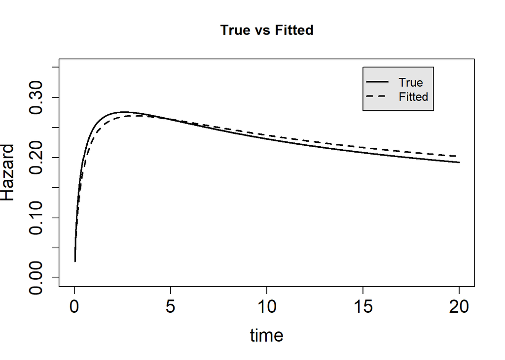

```r
# True vs fitted baseline hazard
h.true <- Vectorize(function(t) hexpw(t,a0,b0,c0))
h.MLE <- Vectorize(function(t) hexpw(t,MLE[1,2],MLE[2,2],MLE[3,2]))
curve(h.true,0,20, ylim = c(0,0.35), lwd = 2, n = 1000, ylab = "Hazard", xlab = "time", main = "True vs Fitted",
      cex.axis = 1.5, cex.lab = 1.5)
curve(h.MLE,0,20, add=T, lwd = 2, lty = 2, ylim = c(0,0.35), n = 1000)
legend(15,0.35, c("True","Fitted"),
       text.col = c("black","black"), col = c("black","black"), lty = c(1, 2),lwd=2,
       merge = TRUE, bg = "gray90")
```

# References

Chen, Y.Q., and N.P. Jewell. 2001. “On a General Class of Semiparametric Hazards Regression Models.” *Biometrika* 88 (3): 687–702.

Chen, Y.Q., and M.C. Wang. 2000. “Analysis of Accelerated Hazards Models.” *Journal of the American Statistical Association* 95 (450): 608–18.

Chen, Y.Q., N.P. Jewell, and J. Yang. 2003. “Accelerated Hazards Model: Method, Theory and Applications.” *Handbook of Statistics* 23: 431–41.

Rubio, F.J., B. Rachet, R. Giorgi, C. Maringe, and A. Belot. 2019. “On Models for the Estimation of the Excess Mortality Hazard in Case of Insufficiently Stratified Life Tables.” *Biostatistics* in press: na–na.

Rubio, F.J., L. Remontet, N.P. Jewell, and A. Belot. 2018. “On a General Structure for Hazard-Based Regression Models: An Application to Population-Based Cancer Research.” *Statistical Methods in Medical Research* in press: na–na.